# Project: Investigating hospital appointment

- Introduction
- Data Wrangling
- Exploratory Data Analysis
- Conclusions

## Introduction

For this project, i use medical appointment No-shows provided on kaggle, which is the information collected from medical appointments in Brazil. The dataset has 110527 samples with 14 columns.

```
Note: It says 'No' if the patient show up and 'Yes' if the patient does'nt show up.
```

- The questions raised are;

  ```
  - are non alcoholic patients more likely to show at their appointment?
  - could gender be related to showing up in the appointment?
  - can patients with diabetes also show up in their appointment?
  ```

```python
#import useful packages
import pandas as pd
import matplotlib.pyplot as plt
import numpy as np
%matplotlib inline
```

## Data Wrangling

### General Properties

```python
#load the dataset
df = pd.read_csv('No_show_appointment.csv')
```

```python
#view first 5 rows
df.head()
```

|  | PatientId | AppointmentID | Gender | ScheduledDay | AppointmentDay | Age | Neighbourhood | Scholarship | Hipertension | Diabetes | Alcoholism | Handcap | SMS_received | No-show |
| --- | --- | --- | --- | --- | --- | --- | --- | --- | --- | --- | --- | --- | --- | --- |
| 0 | 2.987250e+13 | 5642903 | F | 2016-04-29T18:38:08Z | 2016-04-29T00:00:00Z | 62 | JARDIM DA PENHA | 0 | 1 | 0 | 0 | 0 | 0 | No |
| 1 | 5.589978e+14 | 5642503 | M | 2016-04-29T16:08:27Z | 2016-04-29T00:00:00Z | 56 | JARDIM DA PENHA | 0 | 0 | 0 | 0 | 0 | 0 | No |
| 2 | 4.262962e+12 | 5642549 | F | 2016-04-29T16:19:04Z | 2016-04-29T00:00:00Z | 62 | MATA DA PRAIA | 0 | 0 | 0 | 0 | 0 | 0 | No |
| 3 | 8.679512e+11 | 5642828 | F | 2016-04-29T17:29:31Z | 2016-04-29T00:00:00Z | 8 | PONTAL DE CAMBURI | 0 | 0 | 0 | 0 | 0 | 0 | No |
| 4 | 8.841186e+12 | 5642494 | F | 2016-04-29T16:07:23Z | 2016-04-29T00:00:00Z | 56 | JARDIM DA PENHA | 0 | 1 | 1 | 0 | 0 | 0 | No |

```python
df.shape
```

```
(110527, 14)
```

```python
df.describe()
```

|  | PatientId | AppointmentID | Age | Scholarship | Hipertension | Diabetes | Alcoholism | Handcap | SMS_received |
| --- | --- | --- | --- | --- | --- | --- | --- | --- | --- |
| count | 1.105270e+05 | 1.105270e+05 | 110527.000000 | 110527.000000 | 110527.000000 | 110527.000000 | 110527.000000 | 110527.000000 | 110527.000000 |
| mean | 1.474963e+14 | 5.675305e+06 | 37.088874 | 0.098266 | 0.197246 | 0.071865 | 0.030400 | 0.022248 | 0.321026 |
| std | 2.560949e+14 | 7.129575e+04 | 23.110205 | 0.297675 | 0.397921 | 0.258265 | 0.171686 | 0.161543 | 0.466873 |
| min | 3.921784e+04 | 5.030230e+06 | -1.000000 | 0.000000 | 0.000000 | 0.000000 | 0.000000 | 0.000000 | 0.000000 |
| 25% | 4.172614e+12 | 5.640286e+06 | 18.000000 | 0.000000 | 0.000000 | 0.000000 | 0.000000 | 0.000000 | 0.000000 |
| 50% | 3.173184e+13 | 5.680573e+06 | 37.000000 | 0.000000 | 0.000000 | 0.000000 | 0.000000 | 0.000000 | 0.000000 |
| 75% | 9.439172e+13 | 5.725524e+06 | 55.000000 | 0.000000 | 0.000000 | 0.000000 | 0.000000 | 0.000000 | 1.000000 |
| max | 9.999816e+14 | 5.790484e+06 | 115.000000 | 1.000000 | 1.000000 | 1.000000 | 1.000000 | 4.000000 | 1.000000 |

The above table shows a description of the whole dataset, by counting the samples, showing each column mean, minimum value, and also maximum value as well.

```python
df.info()
```

```
<class 'pandas.core.frame.DataFrame'>
RangeIndex: 110527 entries, 0 to 110526
Data columns (total 14 columns):
PatientId         110527 non-null float64
AppointmentID     110527 non-null int64
Gender            110527 non-null object
ScheduledDay      110527 non-null object
AppointmentDay    110527 non-null object
Age               110527 non-null int64
Neighbourhood     110527 non-null object
Scholarship       110527 non-null int64
Hipertension      110527 non-null int64
Diabetes          110527 non-null int64
Alcoholism        110527 non-null int64
Handcap           110527 non-null int64
SMS_received      110527 non-null int64
No-show           110527 non-null object
dtypes: float64(1), int64(8), object(5)
memory usage: 11.8+ MB
```

The above information clearly shows that there are no missing values in the dataset

### Data Cleaning

Also in the dataset the 'Age' column have a value of -1, therefore the row with such data will be dropped.

Finaly, in the No-show column the values currently 'No' means the patient has shown up, and 'Yes' means the patient has'nt shown up in the appointment.

```python
#the rows of age == -1 are dropped
df.drop(df[df['Age'] == -1].index, inplace =True)
```

Droping column where Age == -1

```python
#unnecessary coulumns are dropped
df.drop([ 'Neighbourhood','ScheduledDay','AppointmentDay','SMS_received','Scholarship', 'Handcap', 'Age'],axis=1,inplace=True)
```

```python
#the description is checked to confirm the dropped row
df.describe()
```

|  | PatientId | AppointmentID | Hipertension | Diabetes | Alcoholism |
| --- | --- | --- | --- | --- | --- |
| count | 1.105260e+05 | 1.105260e+05 | 110526.000000 | 110526.000000 | 110526.000000 |
| mean | 1.474934e+14 | 5.675304e+06 | 0.197248 | 0.071865 | 0.030400 |
| std | 2.560943e+14 | 7.129544e+04 | 0.397923 | 0.258266 | 0.171686 |
| min | 3.921784e+04 | 5.030230e+06 | 0.000000 | 0.000000 | 0.000000 |
| 25% | 4.172536e+12 | 5.640285e+06 | 0.000000 | 0.000000 | 0.000000 |
| 50% | 3.173184e+13 | 5.680572e+06 | 0.000000 | 0.000000 | 0.000000 |
| 75% | 9.438963e+13 | 5.725523e+06 | 0.000000 | 0.000000 | 0.000000 |
| max | 9.999816e+14 | 5.790484e+06 | 1.000000 | 1.000000 | 1.000000 |

```python
#check if the rows are dropped
df.info()
```

```
<class 'pandas.core.frame.DataFrame'>
Int64Index: 110526 entries, 0 to 110526
Data columns (total 7 columns):
PatientId        110526 non-null float64
AppointmentID    110526 non-null int64
Gender           110526 non-null object
Hipertension     110526 non-null int64
Diabetes         110526 non-null int64
Alcoholism       110526 non-null int64
No-show          110526 non-null object
dtypes: float64(1), int64(4), object(2)
memory usage: 6.7+ MB
```

Replacing values (No, Yes) to (Yes, No) respectively.

```python
#column names are changed to lowercase
new_column_names = {'PatientId': 'patient_id', 'AppointmentID': 'appointment_id',
                    'Gender': 'gender', 'ScheduledDay': 'scheduled_day',
                    'AppointmentDay': 'appointment_day',
                    'Scholarship': 'scholarship', 'Hipertension' :'hipertension', 'No-show': 'showed'}
```

```python
df.rename(columns= new_column_names, inplace=True)
```

```python
#the values yes,no are changed to no,yes respectively
df['showed'].replace(['Yes', 'No'], ['No','Yes'], inplace=True)
```

```python
#view first rows to see the changes made
df.head()
```

|  | patient_id | appointment_id | gender | hipertension | Diabetes | Alcoholism | showed |
| --- | --- | --- | --- | --- | --- | --- | --- |
| 0 | 2.987250e+13 | 5642903 | F | 1 | 0 | 0 | Yes |
| 1 | 5.589978e+14 | 5642503 | M | 0 | 0 | 0 | Yes |
| 2 | 4.262962e+12 | 5642549 | F | 0 | 0 | 0 | Yes |
| 3 | 8.679512e+11 | 5642828 | F | 0 | 0 | 0 | Yes |
| 4 | 8.841186e+12 | 5642494 | F | 1 | 1 | 0 | Yes |

## Exploratory Data Analysis

### QUESTION 1( are non alcoholic patients more likely to show at their appointment?)

```python
#copy the data to df_1
df_1 = df.copy()
```

```python
df.Alcoholism.value_counts()
```

```
0    107166
1      3360
Name: Alcoholism, dtype: int64
```

The above column shows the number of alcoholic and non-alcoholic patients in the dataset

```python
#for alcoholic patients and showing up
alcoholic = df.query('Alcoholism == 1')
alcoholic_showedup_count = alcoholic.groupby('showed')['patient_id'].count()
alcoholic_showedup_proportion = alcoholic_showedup_count/alcoholic_showedup_count.sum()
print(alcoholic_showedup_proportion)
```

```
showed
No     0.201488
Yes    0.798512
Name: patient_id, dtype: float64
```

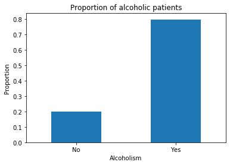

```python
#the proportion of alcoholic patients
alcoholic_showedup_proportion.plot(kind='bar')
plt.title('Proportion of alcoholic patients')
plt.ylabel('Proportion')
plt.xlabel('Alcoholism')
plt.xticks(rotation=0)
plt.show();
```

The above query shows that about 79.9% of alcoholic patients show up in their appointment, and only 20.1% doesnt show up in their appointment.

```python
#for non patients and showing up
non_alcoholic = df.query('Alcoholism == 0')
non_alcoholic_showedup_count = non_alcoholic.groupby('showed')['patient_id'].count()
non_alcoholic_showedup_proportion = non_alcoholic_showedup_count/non_alcoholic_showedup_count.sum()
print(non_alcoholic_showedup_proportion)
```

```
showed
No     0.201948
Yes    0.798052
Name: patient_id, dtype: float64
```

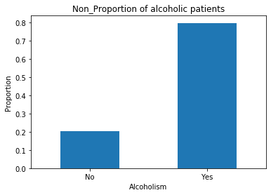

```python
non_alcoholic_showedup_proportion.plot(kind='bar')
plt.title('Non_Proportion of alcoholic patients')
plt.ylabel('Proportion')
plt.xlabel('Alcoholism')
plt.xticks(rotation=0)
plt.show();
```

The above query also shows that around 79.8% of non-alcoholic show in their appointment, and only 20.2% doesnt show up

## Research Question 2 (could gender be related to showing up in the appointment?)

```python
df.gender.value_counts()
```

```
F    71839
M    38687
Name: gender, dtype: int64
```

The above column shows that Female patient almost doubles the number of male patients in the dataset

```python
# proprtion of each gender for those who showed up
showed_up = df_1.query('showed == "Yes"')
showedup_gender_count = showed_up.groupby('gender')['patient_id'].count()
showedup_gender_prop = showedup_gender_count/showedup_gender_count.sum()
showedup_gender_prop.rename(index = {'F': 'Female', 'M': 'Male'}, inplace=True)
showedup_gender_prop.name = 'Gender'

print(showedup_gender_prop)
```

```
gender
Female    0.648985
Male      0.351015
Name: Gender, dtype: float64
```

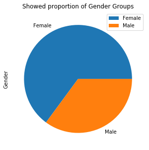

```python
# Plot proportion of gender groups in showing up
showedup_gender_prop.plot(kind='pie', figsize=(7,5))
plt.title('Showed proportion of Gender Groups')
plt.xticks(rotation=0)
plt.legend();
```

```python
print(showedup_gender_prop)
```

```
gender
Female    0.648985
Male      0.351015
Name: Gender, dtype: float64
```

From the above distribution about **64.9%** of those who showed up where Females, while **35.1** where Male.

#### could hipertension of either male or female patient be related to showing up in their appoinment ?

```python
df.groupby('gender')['hipertension'].value_counts()
```

```
gender  hipertension
F       0               56500
        1               15339
M       0               32225
        1                6462
Name: hipertension, dtype: int64
```

## Research Question 3 (can patients with diabetes also show up in their appointment?)

```python
df.Diabetes.value_counts()
```

```
0    102583
1      7943
Name: Diabetes, dtype: int64
```

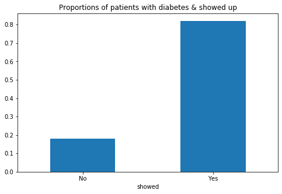

```python
# Calculate show up proportion of patients with health_scholarship
#for alcoholic patients and showing up
Diabetes = df.query('Diabetes == 1')
Diabetes_showedup_count = Diabetes.groupby('showed')['patient_id'].count()
Diabetes_showedup_proportion = Diabetes_showedup_count/Diabetes_showedup_count.sum()
Diabetes_showedup_proportion.name = 'Diabetes & showed up?'
#no_health_scholarship_showedup_proportion.name = 'No health_scholarship & showed up?'

# Plot the proportion
Diabetes_showedup_proportion.plot(kind='bar', figsize=(8, 5))
plt.title('Proportions of patients with diabetes & showed up')
plt.xticks(rotation=0)
plt.show();
```

```python
print(Diabetes_showedup_proportion)
```

```
showed
No     0.180033
Yes    0.819967
Name: Diabetes & showed up?, dtype: float64
```

The above query clearly shows that around 82.0% of patients with diabetes show up, and only 18.00% did not show up.

[figure not shown]

```python
non_Diabetes = df.query('Diabetes == 0')
non_Diabetes_showedup_count = non_Diabetes.groupby('showed')['patient_id'].count()
non_Diabetes_showedup_proportion = non_Diabetes_showedup_count/non_Diabetes_showedup_count.sum()
non_Diabetes_showedup_proportion.name = 'non_diabetes & showed up?'
#no_health_scholarship_showedup_proportion.name = 'No health_scholarship & showed up?'

# Plot the proportion
non_Diabetes_showedup_proportion.plot(kind='bar', figsize=(8, 5))
plt.title('Proportions of patients with diabetes & showed up')
plt.xticks(rotation=0)
plt.show();
```

```python
print(non_Diabetes_showedup_proportion)
```

```
showed
No     0.20363
Yes    0.79637
Name: non_diabetes & showed up?, dtype: float64
```

The above query clearly shows that around 79.6% of patients without diabetes show up in their appointment, and 20.4% did not show up.

### Limitations

- The 'Age' column has a negative value of age, so i had to exclude rows(samples) with such values in the investigation.
- This generalization does not include neighbourhood, appointmentDay, sms_received, scholarship and handcap columns(datas).

## Conclusions

### QUESTION 1( are non alcoholic patients more likely to show at their appointment?)

Around **79.9%** of alcoholic patients showed up at their appointment and on the other hand, around **79.8%** of non-alcoholic patients showed up. Hence; non alcoholic patients are not likely the ones that show up at their appointment, which means alcohlism is not to considered to showing up in appointment.